# 9 Time-to-event setup

In this session, we will briefly give an example on how to create a time-to-event setup and run a Kaplan-Meier estimator as well as plotting the 1-Kaplan-Meier curves (all-cause mortality risk plots). No statistical theory will be covered.

## 9.1 Make a script

First, make a script where we can save our code. Choose either R Markdown/Quarto or R Script.

Name it “mortality”.

Save it in the folder R.

## 9.2 Load packages

Load the packages we will need under a section called “Load packages”.

```r
library(tidyverse)
library(survival)
library(ggsurvfit)
library(glue)
library(writexl)
```

Add new packages to the `DESCRIPTION` file.

```r
usethis::use_package("survival")
usethis::use_package("glue")
usethis::use_package("writexl")
```

## 9.3 Load data

```r
data_pop_mi <- readRDS(here::here("data/data_pop_mi.rds"))

basic_data <- readRDS(here::here("data-raw/basic_data.rds"))
```

## 9.4 Time-to-event setup

Now, we will setup our dataset for a time-to-event analysis. We will follow patients from `index_date` until death, 1 year of follow-up, or December 31, 2024, whichever occurred first.

*Note:* We here just assume no emigration.

### 9.4.1 Step 01: Add death date

```r
data_tte <- data_pop_mi |>
  select(id, index_date) |>
  left_join(basic_data |> select(id, sex, death_date), by = "id")

data_tte
```

```
# A tibble: 4,000 × 4
   id    index_date sex   death_date
   <fct> <date>     <fct> <date>
 1 212   2014-07-18 1     NA
 2 483   2017-12-10 2     NA
 3 731   2023-07-27 2     NA
 4 949   2021-11-03 1     NA
 5 981   2020-08-05 2     NA
 6 982   2015-05-22 2     NA
 7 1123  2015-07-25 1     NA
 8 2166  2016-09-30 1     NA
 9 2469  2023-08-26 2     2024-04-23
10 2870  2010-09-03 1     NA
# ℹ 3,990 more rows
```

### 9.4.2 Step 02: Generate stop dates

```r
data_tte <- data_tte |>
  dplyr::mutate(
    max_fu = lubridate::add_with_rollback(lubridate::ymd(index_date), lubridate::years(1)), # 1 year of follow-up
    stop_study = lubridate::ymd("2024-12-31")) # stop of study

data_tte
```

```
# A tibble: 4,000 × 6
   id    index_date sex   death_date max_fu     stop_study
   <fct> <date>     <fct> <date>     <date>     <date>
 1 212   2014-07-18 1     NA         2015-07-18 2024-12-31
 2 483   2017-12-10 2     NA         2018-12-10 2024-12-31
 3 731   2023-07-27 2     NA         2024-07-27 2024-12-31
 4 949   2021-11-03 1     NA         2022-11-03 2024-12-31
 5 981   2020-08-05 2     NA         2021-08-05 2024-12-31
 6 982   2015-05-22 2     NA         2016-05-22 2024-12-31
 7 1123  2015-07-25 1     NA         2016-07-25 2024-12-31
 8 2166  2016-09-30 1     NA         2017-09-30 2024-12-31
 9 2469  2023-08-26 2     2024-04-23 2024-08-26 2024-12-31
10 2870  2010-09-03 1     NA         2011-09-03 2024-12-31
# ℹ 3,990 more rows
```

### 9.4.3 Step 03. Select first of death, max follow-up, or study stop

```r
data_tte <- data_tte |>
  mutate(across(c(death_date, max_fu, stop_study), ~ lubridate::ymd(.x)), # ensure that dates are <date> format
         end_date = pmin(death_date, max_fu, stop_study, na.rm = TRUE) # Follow-up ends at death, 1 year, or study stop — whichever comes
  )

data_tte
```

```
# A tibble: 4,000 × 7
   id    index_date sex   death_date max_fu     stop_study end_date
   <fct> <date>     <fct> <date>     <date>     <date>     <date>
 1 212   2014-07-18 1     NA         2015-07-18 2024-12-31 2015-07-18
 2 483   2017-12-10 2     NA         2018-12-10 2024-12-31 2018-12-10
 3 731   2023-07-27 2     NA         2024-07-27 2024-12-31 2024-07-27
 4 949   2021-11-03 1     NA         2022-11-03 2024-12-31 2022-11-03
 5 981   2020-08-05 2     NA         2021-08-05 2024-12-31 2021-08-05
 6 982   2015-05-22 2     NA         2016-05-22 2024-12-31 2016-05-22
 7 1123  2015-07-25 1     NA         2016-07-25 2024-12-31 2016-07-25
 8 2166  2016-09-30 1     NA         2017-09-30 2024-12-31 2017-09-30
 9 2469  2023-08-26 2     2024-04-23 2024-08-26 2024-12-31 2024-04-23
10 2870  2010-09-03 1     NA         2011-09-03 2024-12-31 2011-09-03
# ℹ 3,990 more rows
```

### 9.4.4 Step 04. Create a time indicator

```r
data_tte <- data_tte |>
  mutate(
         time = as.numeric(difftime(end_date, index_date, units = "days")) # here in days
         )

data_tte
```

```
# A tibble: 4,000 × 8
   id    index_date sex   death_date max_fu     stop_study end_date    time
   <fct> <date>     <fct> <date>     <date>     <date>     <date>     <dbl>
 1 212   2014-07-18 1     NA         2015-07-18 2024-12-31 2015-07-18   365
 2 483   2017-12-10 2     NA         2018-12-10 2024-12-31 2018-12-10   365
 3 731   2023-07-27 2     NA         2024-07-27 2024-12-31 2024-07-27   366
 4 949   2021-11-03 1     NA         2022-11-03 2024-12-31 2022-11-03   365
 5 981   2020-08-05 2     NA         2021-08-05 2024-12-31 2021-08-05   365
 6 982   2015-05-22 2     NA         2016-05-22 2024-12-31 2016-05-22   366
 7 1123  2015-07-25 1     NA         2016-07-25 2024-12-31 2016-07-25   366
 8 2166  2016-09-30 1     NA         2017-09-30 2024-12-31 2017-09-30   365
 9 2469  2023-08-26 2     2024-04-23 2024-08-26 2024-12-31 2024-04-23   241
10 2870  2010-09-03 1     NA         2011-09-03 2024-12-31 2011-09-03   365
# ℹ 3,990 more rows
```

You may wish to check some restrictions:

```r
# No negative time values
min(data_tte[["time"]])
```

```
[1] 1
```

```r
# Max follow-up time
max(data_tte[["time"]])
```

```
[1] 366
```

```r
# Max date of stop
max(data_tte[["end_date"]])
```

```
[1] "2024-12-31"
```

### 9.4.5 Step 05. Create a status indicator

```r
data_tte <- data_tte |>
  mutate(
         status =
           case_when(
             !is.na(death_date) & death_date == end_date ~ 1, # if stop of follow-up due to death
             TRUE ~ 0 # if censored due to 1 year of follow-up or study stop
             )
         ) |>
  select(-c(max_fu, stop_study))

data_tte
```

```
# A tibble: 4,000 × 7
   id    index_date sex   death_date end_date    time status
   <fct> <date>     <fct> <date>     <date>     <dbl>  <dbl>
 1 212   2014-07-18 1     NA         2015-07-18   365      0
 2 483   2017-12-10 2     NA         2018-12-10   365      0
 3 731   2023-07-27 2     NA         2024-07-27   366      0
 4 949   2021-11-03 1     NA         2022-11-03   365      0
 5 981   2020-08-05 2     NA         2021-08-05   365      0
 6 982   2015-05-22 2     NA         2016-05-22   366      0
 7 1123  2015-07-25 1     NA         2016-07-25   366      0
 8 2166  2016-09-30 1     NA         2017-09-30   365      0
 9 2469  2023-08-26 2     2024-04-23 2024-04-23   241      1
10 2870  2010-09-03 1     NA         2011-09-03   365      0
# ℹ 3,990 more rows
```

### 9.4.6 Step 06. Fit the model

```r
fit_km <- survfit(Surv(time, status) ~ sex, data = data_tte)
```

### 9.4.7 Step 07. Check the output

You may wish to check the output at certain time points

```r
time_points <- c(0, 30, 30*3, 30*6, 30*9, 30*12)

print(summary(fit_km, times = time_points))
```

```
Call: survfit(formula = Surv(time, status) ~ sex, data = data_tte)

                sex=1
 time n.risk n.event survival std.err lower 95% CI upper 95% CI
    0   2500       0    1.000 0.00000        1.000        1.000
   30   2185     304    0.878 0.00655        0.865        0.891
   90   2115      44    0.860 0.00695        0.847        0.874
  180   2018      68    0.832 0.00750        0.818        0.847
  270   1947      44    0.814 0.00782        0.799        0.830
  360   1870      46    0.795 0.00814        0.779        0.811

                sex=2
 time n.risk n.event survival std.err lower 95% CI upper 95% CI
    0   1500       0    1.000 0.00000        1.000        1.000
   30   1332     160    0.893 0.00799        0.878        0.909
   90   1289      26    0.875 0.00855        0.859        0.892
  180   1251      22    0.860 0.00898        0.843        0.878
  270   1211      21    0.846 0.00937        0.828        0.864
  360   1178      17    0.834 0.00968        0.815        0.853
```

### 9.4.8 Step 08. Plot, quick and dirty

You can plot the Kaplan-Meier curve very easy with `ggsurvfit`. You can customise with `ggplot2`.

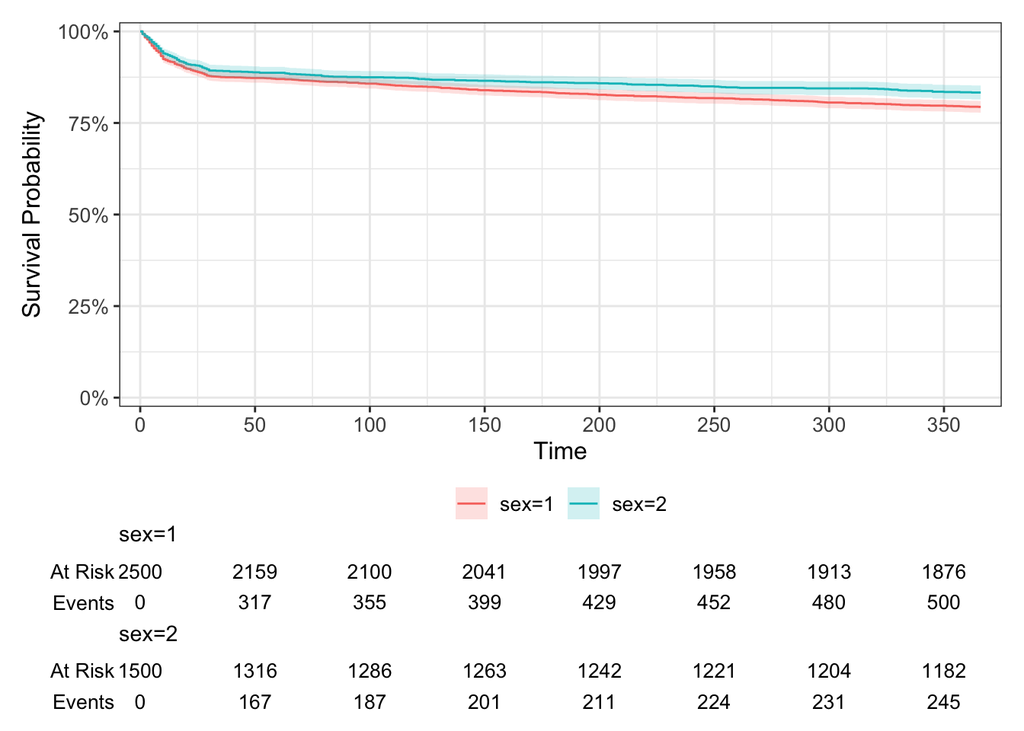

```r
ggsurvfit(fit_km) +
  add_confidence_interval() +
  add_risktable() +
  add_quantile(y_value = 0.6, color = "gray50", linewidth = 0.75) +
  scale_ggsurvfit()
```

### 9.4.9 Step 09. Alternative result extraction and plotting

There are several different ways to do this. Probably also some more elegant ways.

#### 9.4.9.1 Explore estimates at specific time points

Lets generate a dataset with mortality risk estimates with 1 day intervals from day 0 until end of follow-up.

```r
max_fu <- max(data_tte$time)
s_fit <- summary(fit_km, times = 0:max_fu)

round_function <- function(x){

  sprintf("%.1f", x)

}

data_mortality <- data.frame(
  time       = s_fit$time,
  n_risk     = s_fit$n.risk,
  n_event    = s_fit$n.event,
  surv       = s_fit$surv,
  strata     = s_fit$strata,
  upper      = s_fit$upper,
  lower      = s_fit$lower
) |>
  mutate(
    group = case_when(
      strata == "sex=1" ~ "Male",
      strata == "sex=2" ~ "Female"
      ),
    group = factor(group, levels = c("Male", "Female")),
    risk_crude = (1-surv)*100,
    ll_crude = (1-upper)*100,
    ul_crude = (1-lower)*100
  ) |>
  select(-c(strata, surv, upper, lower)) |>
  mutate(
    across(
      c(
        risk_crude, ll_crude, ul_crude
      ),
      ~ round_function(.x)
    )
  )

head(data_mortality,20)
```

```
   time n_risk n_event group risk_crude ll_crude ul_crude
1     0   2500       0  Male        0.0      0.0      0.0
2     1   2500      18  Male        0.7      0.4      1.1
3     2   2482      23  Male        1.6      1.1      2.1
4     3   2458      14  Male        2.2      1.6      2.8
5     4   2444      21  Male        3.0      2.4      3.7
6     5   2422      22  Male        3.9      3.2      4.7
7     6   2400      18  Male        4.6      3.8      5.5
8     7   2381      16  Male        5.3      4.4      6.2
9     8   2365      11  Male        5.7      4.8      6.6
10    9   2353      25  Male        6.7      5.7      7.7
11   10   2327      21  Male        7.6      6.5      8.6
12   11   2306       6  Male        7.8      6.7      8.9
13   12   2299       7  Male        8.1      7.0      9.2
14   13   2292       5  Male        8.3      7.2      9.4
15   14   2286       2  Male        8.4      7.3      9.4
16   15   2284      12  Male        8.9      7.7     10.0
17   16   2272       6  Male        9.1      8.0     10.2
18   17   2266       4  Male        9.3      8.1     10.4
19   18   2261       7  Male        9.5      8.4     10.7
20   19   2253      10  Male        9.9      8.8     11.1
```

#### 9.4.9.2 Extract results

Extract results and print in different formats

```r
results_mortality <-
  data_mortality |>
  filter(time %in% time_points,
         time != 0) |>
  select(time, group, risk_crude, ll_crude, ul_crude)

results_mortality
```

```
   time  group risk_crude ll_crude ul_crude
1    30   Male       12.2     10.9     13.5
2    90   Male       14.0     12.6     15.3
3   180   Male       16.8     15.3     18.2
4   270   Male       18.6     17.0     20.1
5   360   Male       20.5     18.9     22.1
6    30 Female       10.7      9.1     12.2
7    90 Female       12.5     10.8     14.1
8   180 Female       14.0     12.2     15.7
9   270 Female       15.4     13.6     17.2
10  360 Female       16.6     14.7     18.5
```

```r
results_mortality |>
  pivot_wider(
    names_from = time,
    values_from = c(risk_crude, ll_crude, ul_crude)
  ) |>
  select(group, ends_with("_30"), ends_with("_90"), ends_with("_180"), ends_with("_270"), ends_with("_360")) |>
mutate(
    risk_30 = glue("{risk_crude_30} ({ll_crude_30}–{ul_crude_30})"),
    risk_90 = glue("{risk_crude_90} ({ll_crude_90}–{ul_crude_90})"),
    risk_180 = glue("{risk_crude_180} ({ll_crude_180}–{ul_crude_180})"),
    risk_270 = glue("{risk_crude_270} ({ll_crude_270}–{ul_crude_270})"),
    risk_360 = glue("{risk_crude_360} ({ll_crude_360}–{ul_crude_360})")
  ) |>
  select(group, risk_30, risk_90, risk_180, risk_270, risk_360)
```

```
# A tibble: 2 × 6
  group  risk_30          risk_90          risk_180         risk_270    risk_360
  <fct>  <glue>           <glue>           <glue>           <glue>      <glue>
1 Male   12.2 (10.9–13.5) 14.0 (12.6–15.3) 16.8 (15.3–18.2) 18.6 (17.0… 20.5 (1…
2 Female 10.7 (9.1–12.2)  12.5 (10.8–14.1) 14.0 (12.2–15.7) 15.4 (13.6… 16.6 (1…
```

#### 9.4.9.3 Plot

We can also plot a mortality risk curve using the same dataset.

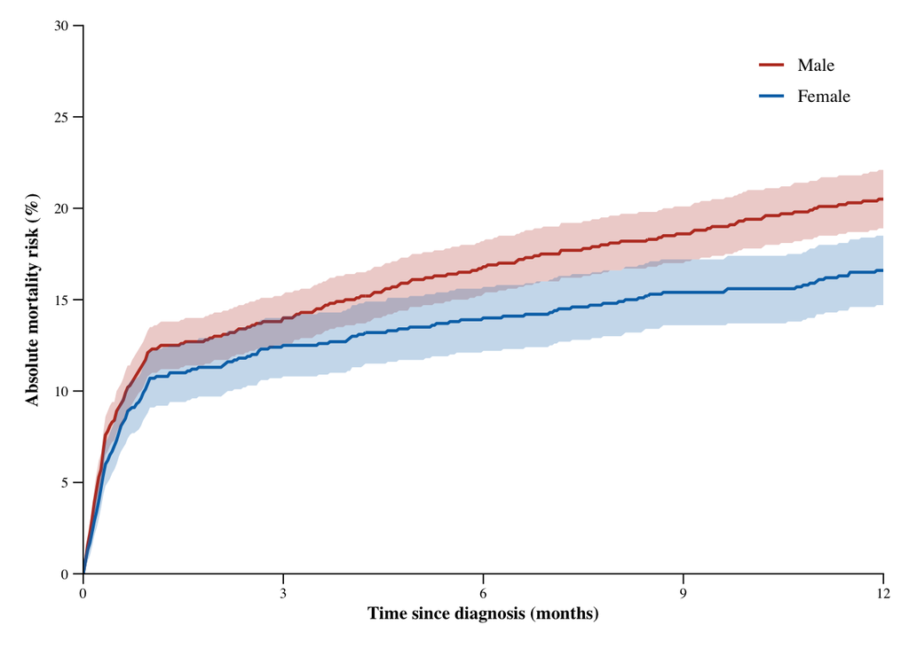

```r
plot_mortality <-
  data_mortality |>
  mutate(across(c(risk_crude, time, ll_crude, ul_crude), ~ as.numeric(.x))) |>
  ggplot(aes(y = risk_crude, x = time, group = group, col = group, fill = group, ymin = ll_crude, ymax = ul_crude)) +
  geom_line(show_legend = T, linewidth = .8) +
  geom_ribbon(alpha = .25, col = NA, linetype = 0, show.legend = F) +
  ggsci::scale_color_nejm() +
  ggsci::scale_fill_nejm() +
  scale_x_continuous(
    name = "Time since diagnosis (months)",
    expand = c(0, 0),
    limits = c(0, 30*12),
    breaks = seq(0, 30*12, 30*3),
    labels = seq(0, 12, 3)
  ) +
  scale_y_continuous(
    name = "Absolute mortality risk (%)",
    limits = c(0, 30),
    expand = c(0, 0),
    breaks = seq(0, 30, 5),
    labels = seq(0, 30, 5)
  ) +
  ggpubr::theme_classic2() +
  theme(
    plot.margin = margin(t = 0.5, r = 0.5, b = 0.5, l = 0.5, unit = "cm"),
    text = element_text(family = "serif", size = 10),
    axis.line = element_line(linewidth = .35),
    axis.ticks = element_line(linewidth = .35),
    axis.ticks.length = unit(.2, "cm"),
    axis.title.x = element_text(face = "bold"),
    axis.title.y = element_text(face = "bold", margin = margin(r = 7)),
    legend.title = element_blank(),
    legend.text = element_text(size = 10),
    legend.position = c(.9, .9)
  )

plot_mortality
```

Adding a risk table can be quite cumbersome but is doable. But we will not look into that for now.

### 9.4.10 Step 10. Save the results

#### 9.4.10.1 Results

```r
write_xlsx(results_mortality, here::here("results/results_mortality.xlsx"))
```

#### 9.4.10.2 Plot

You can save the `ggplot2` object through the save function in he Plots viewer. However, you can also do it using `ggsave.`

```r
ggsave(
  filename = here::here("results/plot_mortality.pdf"),
  plot = plot_mortality,
  device = cairo_pdf,
  width = 8,
  height = 6,
  units = "in",
  dpi = 600
)
```